# Homework 3-1

- Show All Code
- Hide All Code
- View Source

Author

Affiliation

Nicholas Adu Gyamfi

Old Dominion University

This homework focuses on a recent paper exploiting a long ago change ([Copyrights and Creativity: Evidence from Italian Opera in the Napoleonic Age](https://doi.org/10.1086/710534) by Giorcelli and Moser, *Journal of Political Economy*, 2020). During the Napoleonic Wars in Italy, copyright laws applying to musical compositions changed in parts of Italy conquered by Napoleon. Copyright laws allow popular artists like song writers to monetize their work. Without them, other artists can perform their songs without compensating them. You should read through the paper before completing this Homework.[^1]

**Important Note**: The data analyzed can be downloaded from the journal web site and come directly from this paper. However, the results you generate may not exactly match those reported in the paper.

### Question 1

Summarize the main research question in the paper, the application analyzed, and why DiD is appropriate for this research question. (**4 Points**)

The main research question from this study seeks to explore the effects of copyright on creativity and quality of operas and other musical compositions in Italy from 1801 on the two states Lombardy and Venetia compared to the other states that did not adopt copyright laws. This paper studies the impact of copyright laws on creativity (the creation of new operas), the quality of music, and the broader set of musical compositions. The document seeks to provide systematic evidence on the causal effects of copyrights and their implications for creativity, innovation, and intellectual property rights.

### Question 2

Use the supplied data from [Giorcelli and Moser (2020)](https://doi.org/10.1086/710534) to answer the following.

1. Read in [`operas_1781_1820.csv`](https://alexcardazzi.github.io/econ400/data/operas_1781-1820.csv) and name it `italy`. (**1 Point**)

```r
italy <- read.csv("https://alexcardazzi.github.io/econ400/data/operas_1781-1820.csv")
```

2. Using the `unique()` function, print the `state` identifiers that are in the treatment group. (**1 Point**)

```r
# Change Column copyright to treat
colnames(italy)[3] = "treat"

states_in_tmt <- unique(italy$state[italy$treat == 1])
states_in_tmt
```

**Output**

```
[1] "venetia"  "lombardy"
```

3. Calculate the number of observations in each of the following groups: treatment group pre-treatment, treatment group post-treatment, control group pre-treatment, control group post-treatment. (**1 Point**)

```r
# treatment group pre-treatment
treat1_post0 <- sum(italy$treat == 1 & italy$post1801 == 0)
cat(paste("Treatment group pre-treatment is", treat1_post0), "\n")

# treatment group post-treatment
treat1_post1 <- sum(italy$treat == 1 & italy$post1801 == 1)
cat(paste("Treatment group post-treatment is", treat1_post1), "\n")

# control group pre-treatment
treat0_post0 <- sum(italy$treat == 0 & italy$post1801 == 0)
cat(paste("Control group pre-treatment is", treat0_post0), "\n")

# control group post-treatment
treat0_post1 <- sum(italy$treat == 0 & italy$post1801 == 1)
cat(paste("Control group post-treatment is", treat0_post1), "\n")
```

**Output**

```
Treatment group pre-treatment is 40
Treatment group post-treatment is 40
Control group pre-treatment is 120
Control group post-treatment is 120
```

4. Report the yearly average of new operas premiered for each state. (**1 Point**)

```r
# Calculate the yearly average of new "operas" premiered for each "state"
agg <- aggregate(italy$operas, list(state = italy$state), mean)
agg
```

**Output**

```
         state     x
1     d_modena 1.000
2      d_parma 1.025
3   gd_tuscany 1.200
4     lombardy 3.100
5  papal_state 2.275
6     sardinia 1.525
7 two_sicilies 3.275
8      venetia 3.025
```

### Question 3

Describe the important components of DiD.

1. Discuss the general assumptions underlying the causal inference method used in the empirical analysis. (**2 Points**)

The parallel trend assumption: This assumption posits that if no treatment had occurred, there would have been no difference between the treatment and control group in the post-treatment period. The parallel assumption is unobservable, it represents the counterfactual of what would have happened in the absence of treatment. Thus, any differential trend in outcome between treatment and control groups after treatment should be attributed to treatment.

Anticipation assumptions: This assumption posits that individuals did not anticipate the treatment before it was implemented. This is because pre-anticipation of the treatment could bias the estimate as individuals would have changed their behavior accordingly.

Stable Unit Treatment Values Assumption (SUTVA): SUTVA assumption posits that there is only one unit of the treatment being evaluated and there is no contamination between the treatment and control groups. Not only this the treatment effect must be constant across all units, thus the treatment status of one unit should not affect the outcome of another unit.

Treatment is not endogenous: This assumption suggests that the assigned treatment is exogenous and unrelated to the outcome variable. When the treatment is endogenous, it is correlated with unobservable factors that also affect the outcome variable thereby violating the exogeneity assumption and causing the estimates to be biased.

2. How do the authors address these assumptions in the paper (if at all)? (**2 Points**)

To address the assumption of SUTVA (Stable Unit Treatment Value Assumption), the authors compare the time series of new operas for states with and without copyrights until 1801. They found no differences in output trends between the two sets of states before the adoption of copyrights. This provides evidence supporting the SUTVA assumption, indicating that the adoption of copyrights had a distinct and significant impact on creative output.

In the case of this study, it is likely that the authors address the anticipation assumption by considering the historical context and the timing of the adoption of copyrights in Lombardy and Venetia. They may have examined whether composers and creators in these regions adjusted their behavior in anticipation of the introduction of copyright protection. This could involve analyzing whether there was a discernible change in creative output or the quality of works leading up to the implementation of copyright laws, as creators may have adjusted their behavior in anticipation of the potential benefits of copyright protection.

To help address potential endogeneity concerns, authors excluding major cities like Milan and Venice from the regressions to assess the impact of these urban centers. They find about 66% increase in creation of operas even after excluding these urban centers, suggesting that the impact of copyrights on creative output extends beyond major city centers.

3. Discuss threats to a causal interpretation of the results. (**2 Points**)

The study faces some potential threats to the causal interpretation of its results.

First, the study may face threats related to the generalizability of the results, as it focuses specifically on Italian opera during the Napoleonic Age. While the findings provide valuable insights into the impact of copyrights on creativity in this context, it is important to consider the applicability of the results to other artistic domains and historical context.

Second is the threat of endogeneity, which refers to the potential for unobserved factors to influence both the adoption of copyrights and creative output. The authors address this issue by excluding major cities like Milan and Venice from the regressions to assess the impact of these urban centers on the creation of operas.

Third is the threat of anticipation, which suggests that creators may adjust their behavior in anticipation of the potential benefits of copyright protection. The study does not explicitly address this assumption, but it likely considers historical trends and uses statistical methods to control for potential anticipation effects in its analysis of the impact of copyrights on creativity in Italian opera.

### Question 4

Replicate the content in Figure 2 using `italy`. *Note*: the lines in this graph might not replicate perfectly, but do your best. (**3 Points**)

```r
# Model for
agg <- aggregate(italy$operas, list(italy$year, italy$treat), mean)

# Plot of DiD Curves
plot(agg$Group.1, agg$x,
     las = 1, type = "n",
     main = "New Operas per State and year in Italy 1781 - 1820",
     xlim = c(1780, 1821),
     ylim = c(0, 8),
     ylab = "Mean New Opera's per year", xlab = "Year")
abline(v = 1801, col = "blue", lty = 2)
legend("bottom", legend = c("Lombardy & Venetia", "Other States"), col = c("blue", "tomato"), lty = c(1, 2), bty = "n", xpd = TRUE, inset = c(0,-0.4), horiz = TRUE)

lines(agg$Group.1[agg$Group.2 == 1],
      agg$x[agg$Group.2 == 1],
      col = "blue")

lines(agg$Group.1[agg$Group.2 == 0],
      agg$x[agg$Group.2 == 0],
      col = "tomato", lty = 2)
```

**Plot**

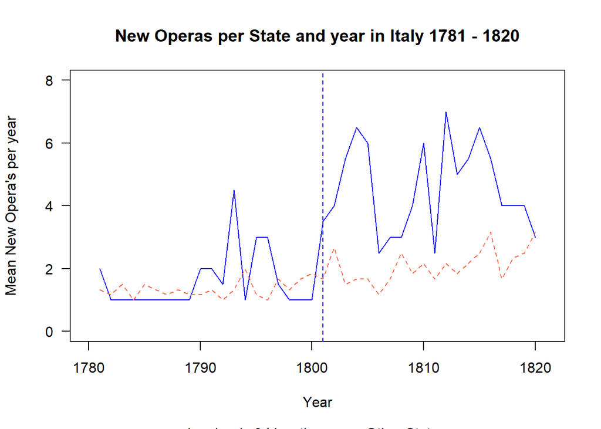

### Question 5

Replicate the main result reported in the paper. Make sure that you follow the guidelines for replicable research in your code. (**3 points**)

1. Estimate a 2x2 DiD model of the form:

$$Y_{st} = \beta_0 + \beta_1 \text{Treat}_s + \beta_2 \text{Post}_t + \delta (\text{Treat}_s \times \text{Post}_t) + \epsilon_{st}$$

```r
r1 <- lm(operas ~ treat + post1801 + treat:post1801, data = italy)
summary(r1)
```

**Output**

```
Call:
lm(formula = operas ~ treat + post1801 + treat:post1801, data = italy)

Residuals:
    Min      1Q  Median      3Q     Max
-3.5500 -0.7021 -0.3500 -0.0833  5.9167

Coefficients:
               Estimate Std. Error t value Pr(>|t|)
(Intercept)      1.3500     0.1349  10.007  < 2e-16 ***
treat            0.2250     0.2698   0.834 0.404963
post1801         0.7333     0.1908   3.844 0.000147 ***
treat:post1801   2.2417     0.3816   5.875 1.07e-08 ***
---
Signif. codes:  0 '***' 0.001 '**' 0.01 '*' 0.05 '.' 0.1 ' ' 1

Residual standard error: 1.478 on 316 degrees of freedom
Multiple R-squared:  0.3154,    Adjusted R-squared:  0.3089
F-statistic: 48.53 on 3 and 316 DF,  p-value: < 2.2e-16
```

2. Replicate the results in Columns (1) and (2) on Table 3 in the paper. Do not worry about replicating the standard errors. Are the results the same as the paper? Are the results the same across both columns?[^2]

```r
# State Fixed Effect and Year Fixed Effect
r2 <- lm(operas ~ as.factor(state) + as.factor(year) + treat:post1801, data = italy)
#summary(r2)

# Year Fixed Effect
r3 <- lm(operas ~ treat + as.factor(year) + treat:post1801, data = italy)
#summary(r3)
```

3. Create a table using `modelsummary` containing coefficients from the three models.

```r
regz <- list(`2x2DiD` = r1,
             `StateFE & Year FE` = r2,
             `YearFE` = r3)

coefz <- c("treat:post1801" = "L&V x Post1801",
           "treat" = "L&V",
           "post1801" = "After 1801",
           "(Intercept)" = "Constant")

gofz <- c("nobs", "r.squared")

modelsummary::modelsummary(regz,
             title = "Effect of Copyright Laws on the creation of new operas",
             estimate = "{estimate}{stars}",
             coef_map = coefz,
             gof_map = gofz)
```

Effect of Copyright Laws on the creation of new operas

|  | 2x2DiD | StateFE & Year FE | YearFE |
| --- | --- | --- | --- |
| L&V x Post1801 | 2.242*** | 2.242*** | 2.242*** |
|  | (0.382) | (0.339) | (0.389) |
| L&V | 0.225 |  | 0.225 |
|  | (0.270) |  | (0.275) |
| After 1801 | 0.733*** |  |  |
|  | (0.191) |  |  |
| Constant | 1.350*** | 0.727 | 1.444** |
|  | (0.135) | (0.505) | (0.537) |
| Num.Obs. | 320 | 320 | 320 |
| R2 | 0.315 | 0.535 | 0.375 |

### Question 6

Discuss your results:

1. What is the interpretation of the causal parameter of interest? Place the causal effect in the context of the setting. (**2 Points**)

In the “2x2DiD”, “StateFE & YearFE”, and “YearFE”, the coefficient for “L&V x Post1801” is 2.242. This represents the interaction effect between the treatment variable (L&V) and the post-1801 period. The coefficient is statistically significant, suggesting a significant difference in the treatment effect before and after 1801. The coefficient of “L&V x Post1801” is positive and indicates a larger treatment effect after 1801 compared to the treatment effect before 1801.

2. How large is the treatment effect as a percentage of the pre-treatment average of the treatment group? (**2 Points**)

```r
avg <- mean(italy$operas[italy$treat == 1 & italy$post1801 == 0], na.rm = TRUE)

tmt_EF <- paste0(round((2.242/avg)*100, 2), "%")

cat(paste("The treatment effect as a percentage of the pre-treatment average of the treated group is", tmt_EF ), "\n")
```

**Output**

```
The treatment effect as a percentage of the pre-treatment average of the treated group is 142.35%
```

### Question 7

Replicate the Event Study in Figure 3 of the paper. (**2 points**)

```r
# Event Study -- ref = year before treatment
# Exclude all values from 1781 to 1790 (ref = 1781:1790)
# Add finite values for xlim
r_es <- fixest::feols(operas ~ i(year, treat, ref = 1781:1790) | state + year, italy)    ## Exclude 1781:1790
fixest::iplot(r_es, ref.line = 1801,  col = "blue", xlim = c(1790, 1820), main = "Event Study: Effect of Copyright Laws on creation of new operas")
abline(v = 1801, col = "tomato")
```

**Plot**

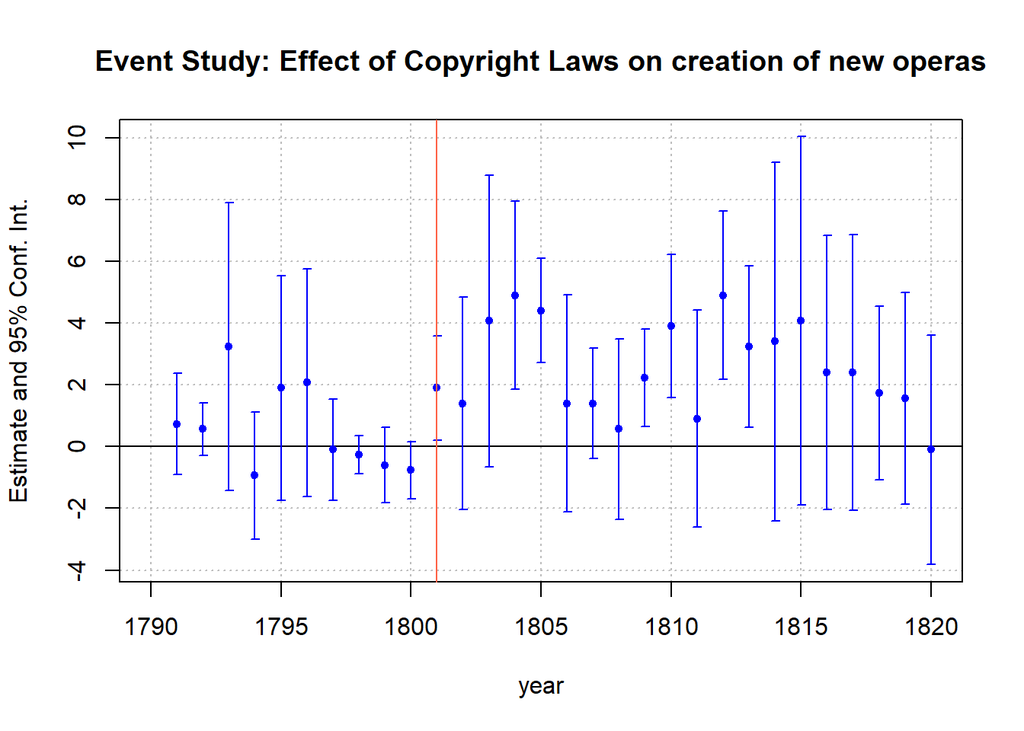

### Question 8

Do you believe the result to be credible in terms of causality and magnitude? Why or why not? (**4 Points**)

Yes, the magnitude and causality of the results appear credible. Copyright laws are primarily enacted to safeguard intellectual property. By legally protecting one’s creativity, individuals can profit from their innovations through royalties and usage fees. Encouraged by the potential returns on their ingenuity, creators are motivated to generate not only a greater quantity but also higher-quality innovative products. This study examines the impact of these protective measures, specifically Copyright laws, on fostering creativity and innovation. The findings indicate that fundamental copyright laws significantly stimulate creativity by fostering the creation of new operas. Moreover, these laws not only enhance the caliber of creative output by incentivizing producers to develop more widely appealing and enduring works but also establish a framework to safeguard the artists’ creations. Thus in essence protecting the artists creation leads to creativity.

The magnitude of the findings is believable, considering that the artistic creations were protected, at least within the borders of Lombardy and Venetia. The ability for composers to negotiate royalty payments and additional compensation for repeat performances likely incentivized them to produce a greater volume of work to capitalize on these financial rewards. Comparing this scenario with other states without similar Copyright laws, it is conceivable that there would be a surge in innovation within the two states where such protective measures were in place thereby justifying the magnitude.

## Footnotes

[^1]: The PDF will be made available on Canvas.
[^2]: You only need to replicate the first two columns.